# 市区町村別犯罪数の計算と可視化

神奈川県の例

[岩田真一郎](https://shinichiro-iwata.github.io/)（ [神奈川大学経済学部](https://www.econ.kanagawa-u.ac.jp/)）

2022-11-19作成，2025-02-11改定

# 1 目的

データを市区町村単位で集計し，可視化．

- 犯罪データにはある時点（年，年度など）の犯罪発生地点（小地域レベル）が示される．これを市区町村単位で集計．
  - ここでは神奈川県警察の[オープンデータサイト](https://www.police.pref.kanagawa.jp/tokei/hanzai_tokei/mesd0145.html)から犯罪発生情報をダウンロードし，市区町村単位で犯罪発生数を数え，可視化．
  - 犯罪発生地点の住所情報を使って対応する緯度経度（ジオコード）を付加し，発生地点や発生分布を可視する方法は[ジオコーディングによる犯罪発生情報の可視化](https://shinichiro-iwata.github.io/geospatial-data-visualization/crime-data-visualization.html)を参照．

パッケージ：`tidyverse`

```r
library(tidyverse)
```

# 2 市区町村単位集計

**犯罪オープンデータのダウンロード**

- [犯罪オープンデータ リンク集｜警察庁Webサイト](https://www.npa.go.jp/toukei/seianki/hanzaiopendatalink.html) > 神奈川県 > [神奈川県警察オープンデータサイト](https://www.police.pref.kanagawa.jp/tokei/hanzai_tokei/mesd0145.html) > 車上ねらい > 令和3年発生（csv 120KB）
  - `fileEncoding="CP932"`：文字化け回避．

```r
car_break <-
  read.csv("kanagawa_2021syazyounerai.csv",
            fileEncoding="CP932")

#車上ねらいの中身，最初の6行
car_break %>%
  head()
```

|  | 罪名 | 手口 | 管轄警察署.発生地. | 管轄交番.駐在所.発生地. | 市区町村コード.発生地. | 都道府県.発生地. | 市区町村.発生地. | 町丁目.発生地. | 発生年月日.始期. | 発生時.始期. | 発生場所 | 発生場所の詳細 | 施錠関係 | 現金被害の有無 |
| --- | --- | --- | --- | --- | --- | --- | --- | --- | --- | --- | --- | --- | --- | --- |
| 1 | 窃盗 | 車上ねらい | 南 | 井土ケ谷 | 141054 | 神奈川県 | 横浜市南区 | 井土ケ谷下町 | 2021/2/12 | 9 | 道路上 | その他 | 施錠せず | あり |
| 2 | 窃盗 | 車上ねらい | 南 | 八幡町 | 141054 | 神奈川県 | 横浜市南区 | 中村町１丁目 | 2021/3/6 | 19 | 道路上 | その他 | 施錠せず | あり |
| 3 | 窃盗 | 車上ねらい | 南 | 八幡町 | 141054 | 神奈川県 | 横浜市南区 | 中村町１丁目 | 2021/9/9 | 18 | 駐車（輪）場 | 駐車（輪）場 | 施錠した | なし |
| 4 | 窃盗 | 車上ねらい | 南 | 八幡町 | 141054 | 神奈川県 | 横浜市南区 | 平楽 | 2021/4/22 | 19 | その他の住宅（３階建て以下共同住宅等） | 駐車（輪）場 | 施錠した | なし |
| 5 | 窃盗 | 車上ねらい | 南 | 六ツ川 | 141054 | 神奈川県 | 横浜市南区 | 六ツ川１丁目 | 2021/4/5 | 19 | その他 | その他 | 施錠した | なし |
| 6 | 窃盗 | 車上ねらい | 南 | 六ツ川 | 141054 | 神奈川県 | 横浜市南区 | 六ツ川１丁目 | 2021/9/7 | 17 | 一戸建住宅 | 駐車（輪）場 | 施錠した | なし |

- `市区町村.発生地.`列（`7`列目）に市区町村が示されているが，日本語のままだと窃盗数を集計できない模様．`rename()`を使い，`city`に変更．
- `city`別，すなわち市区町村別にまとめて（`group_by()`），観測数（＝窃盗数）をカウント（`n()`）．

```r
car_break %>%
  rename(city=7) ->
  car_break2

car_break2 %>%
  group_by(city) %>%
  summarise("窃盗数"=n()) ->
  car_break2

#car_break2の中身
car_break2
```

| city | 窃盗数 |
| --- | --- |
|  | 2 |
| 三浦市 | 7 |
| 中井町 | 3 |
| 伊勢原市 | 12 |
| 南足柄市 | 18 |
| 厚木市 | 28 |
| 大井町 | 1 |
| 大和市 | 57 |
| 大磯町 | 2 |
| 寒川町 | 6 |

[output cut: 43 more lines]

- 作業フォルダ内に市区町村単位のデータを作成．csvファイル（`car_break2.csv`）形式の場合．

```r
#csvファイル作成
car_break2 %>%
  write.csv("car_break2.csv", row.names=FALSE)
```

# 3 地図上への可視化

**境界データのダウンロード**

- [国土数値情報ダウンロードサービス](https://nlftp.mlit.go.jp/ksj/) > 行政区域（ポリゴン） > 神奈川県 > 令和3年
  - ダウンロードしたZIPファイルは同じフォルダー（ディレクトリ）に納め，ZIPファイルを選択 > 右クリック > すべて展開 > 展開先の選択とファイルの選択 > 展開を実行する．展開後は最初にダウンロードしたZIPファイルを削除．
  - `read_sf()`：シェープファイル読込

パッケージ：`sf`

```r
library(sf)

Kanagawa_map <-
  read_sf("N03-20210101_14_GML/N03-21_14_210101.shp")
```

統計データとシェープファイルの合併のための準備．

- 市区町村コードで統計データとシェープファイルを合併（`left_join()`）．
  - **注意**：car_breakの市区町村コードは6桁（整数型）に対して，行政区域（Kanagawa_map）の市区町村コード（`N03_007`）は5桁（文字型）．そこで，car_breakの市区町村コード を5桁（文字型）に変換（`str_sub()`，`as.character()`）．

```r
#5列目の市区町村コード.発生地.をcity_codeに列名変更
car_break %>%
  rename(city_code=5) ->
  car_break3

#city_codeを文字型，5桁に変換
car_break3 %>%
  mutate(city_code=as.character(city_code)) %>%
  mutate(city_code=str_sub(city_code,
                           start=1, end=5))->
  car_break3

#市区町村ごとの車上ねらい窃盗数を計算
car_break3 %>%
  group_by(city_code) %>%
  summarise("窃盗数"=n()) ->
  car_break3

#データの合併
Kanagawa_map <-
  left_join(Kanagawa_map, car_break3,
            by=c("N03_007"="city_code"))
```

**可視化**

- `theme_dark()`を利用して背景を暗色に指示．
- 窃盗数ゼロの地区の塗りつぶしは濃い灰色に指示（`na.value="darkgray"`）．

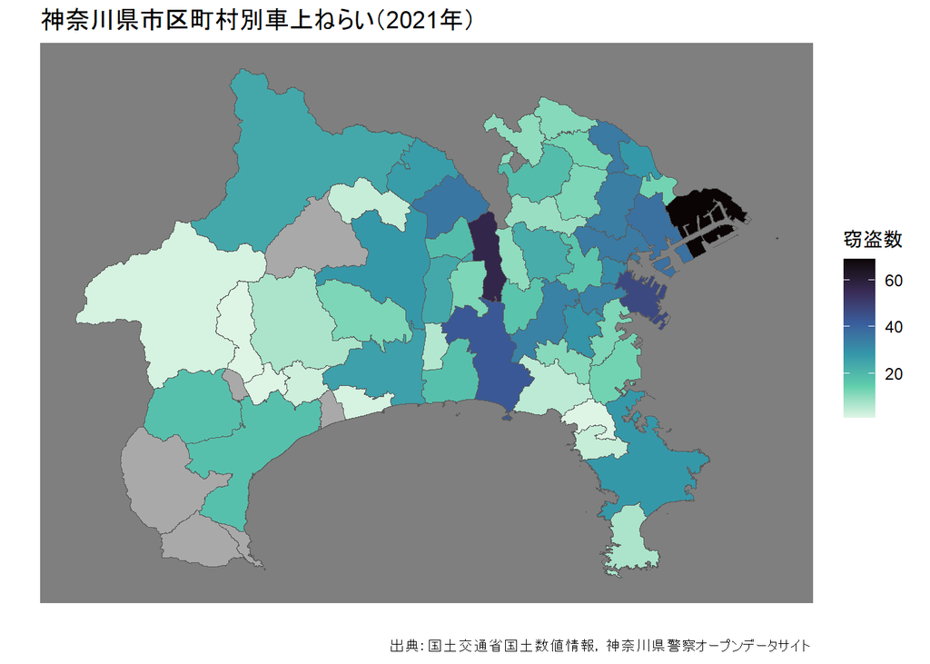

```r
ggplot()+
  geom_sf(data=Kanagawa_map, aes(fill=窃盗数))+
  scale_fill_viridis_c(option="G", direction=-1,
                       na.value="darkgray")+
  labs(fill="窃盗数", x="", y="",
  caption="出典：国土交通省国土数値情報，神奈川県警察オープンデータサイト")+
  ggtitle("神奈川県市区町村別車上ねらい（2021年）")+
  coord_sf(datum=NA)+
  theme_dark()
```

**Rによる地理空間データの可視化**

- チュートリアル[ホーム](https://shinichiro-iwata.github.io/geospatial-data-visualization/)